# NBA 2020 Season Statistics Analysis

## By: Andy Babay and Melvin Molina

# Introduction

For our project we decided to analyze the NBA 2020 season. Although it was a very "different" season to say the very least considering the ongoing Covid-19 pandemic we are facing. The statistics attracted us enough to focus our project on it. We will be going into the details regarding pay, age, and positional statistics. With the usage of many libraries including, but not exclusive to pandas, sklearn, and numpy. This project will solely analyze the 2020 NBA season. Meaning, the data we will be gathering and conducting our analysis on will solely by on this past season. As a needed reminder, the Los Angeles Lakers are the current NBA Champions. Lastly, before we begin our data analysis, rest in paradise Kobe Bryant.

```python
import requests
import pandas as pd
from lxml import html
import csv
from sklearn import linear_model
from sklearn.linear_model import Ridge
from datacleaner import autoclean
import pandas as p
from bs4 import BeautifulSoup
import sklearn.linear_model as lm
from sklearn.metrics import mean_squared_error
from sklearn.metrics import explained_variance_score
import statsmodels.formula.api as sm
from bokeh.models import Jitter
from sklearn import linear_model
from sklearn.feature_selection import f_regression
from sklearn.feature_selection import SelectKBest
# recursive feature selection (feature selection)
from sklearn.feature_selection import RFE
import re
import numpy as np
import matplotlib.pyplot as plt
import seaborn as sns
from sklearn.cluster import KMeans
```

# Retreiving Data

To begin our data analysis it is important to source our information from somewhere legitament. For our project we will be using https://www.basketball-reference.com. This site is known for having a mecca of NBA statistics so it's the perfect spot for us to start

# Organizing Data

Once we have read in our data via BeautifulSoup, we begin to add the data into our overall dataframe in order to further analyze our information better. We place the data into seperate arrays, which will allow us to then converge the arrays with ease, due to the synchronous processing.

```python
r = requests.get('https://www.basketball-reference.com/leagues/NBA_2020_per_game.html').text
data = html.fromstring(r)
soup = BeautifulSoup(r, 'html.parser')

player = []
position = []
age = []
team = []
games = []
games_started = []
mins_per_g = []
fg_per_g = []
fga_per_g = []
fg_pct = []
fg3_per_g = []
fg3a_per_g = []
fg3_pct = []
fg2_per_g = []
fg2a_per_g = []
fg2_pct = []
efg_pct = []
efg_pct = []
ft_per_g = []
fta_per_g = []
ft_pct = []
ft_pct = []
orb_per_g = []
drb_per_g = []
trb_per_g = []
ast_per_g = []
stl_per_g = []
blk_per_g = []
tov_per_g = []
pf_per_g = []
pts_per_g = []


for i in soup.find_all(attrs={"data-stat": "player"}):
    if(i.text!='Player'):
        player.append(i.text)

for i in soup.find_all(attrs={"data-stat": "pos"}):
    if(i.text!='Pos'):
        position.append(i.text)

for i in soup.find_all(attrs={"data-stat": "age"}):
    if(i.text!='Age'):
        age.append(int(i.text))

for i in soup.find_all(attrs={"data-stat": "team_id"}):
    if(i.text!='Tm'):
        team.append(i.text)

for i in soup.find_all(attrs={"data-stat": "g"}):
    if(i.text!='G'):
        games.append(int(i.text))

for i in soup.find_all(attrs={"data-stat": "gs"}):
    if(i.text!='GS'):
        games_started.append(int(i.text))

for i in soup.find_all(attrs={"data-stat": "mp_per_g"}):
    if(i.text!='MP'):
        if(len(i.text)<=0):
            mins_per_g.append(None)
        else:
            mins_per_g.append(float(i.text))

for i in soup.find_all(attrs={"data-stat": "fg_per_g"}):
    if(i.text!='FG'):
        if(len(i.text)<=0):
            fg_per_g.append(None)
        else:
            fg_per_g.append(float(i.text))

for i in soup.find_all(attrs={"data-stat": "fga_per_g"}):
    if(i.text!='FGA'):
        if(len(i.text)<=0):
            fg_per_g.append(None)
        else:
            fga_per_g.append(float(i.text))

for i in soup.find_all(attrs={"data-stat": "fg_pct"}):
    if(i.text!='FG%'):
        if(len(i.text)<=0):
            fg_pct.append(None)
        else:
            fg_pct.append(float(i.text))

for i in soup.find_all(attrs={"data-stat": "fg3_per_g"}):
    if(i.text!='3P'):
        fg3_per_g.append(float(i.text))
for i in soup.find_all(attrs={"data-stat": "fg3a_per_g"}):
    if(i.text!='3PA'):
        fg3a_per_g.append(float(i.text))

for i in soup.find_all(attrs={"data-stat": "fg3_pct"}):
    if(i.text!='3P%'):
        if(len(i.text)<=0):
            fg3_pct.append(None)
        else:
            fg3_pct.append(float(i.text))

for i in soup.find_all(attrs={"data-stat": "fg2_per_g"}):
    if(i.text!='2P'):
        fg2_per_g.append(float(i.text))

for i in soup.find_all(attrs={"data-stat": "fg2a_per_g"}):
    if(i.text!='2PA'):
        fg2a_per_g.append(float(i.text))
for i in soup.find_all(attrs={"data-stat": "fg2_pct"}):
    if(i.text!='2P%'):
        if(len(i.text)<=0):
            fg2_pct.append(None)
        else:
            fg2_pct.append(float(i.text))
for i in soup.find_all(attrs={"data-stat": "efg_pct"}):
    if(i.text!='eFG%'):
        if(len(i.text)<=0):
            efg_pct.append(None)
        else:
            efg_pct.append(float(i.text))
for i in soup.find_all(attrs={"data-stat": "ft_per_g"}):
    if(i.text!='FT'):
        ft_per_g.append(float(i.text))
for i in soup.find_all(attrs={"data-stat": "fta_per_g"}):
    if(i.text!='FTA'):
        fta_per_g.append(float(i.text))
for i in soup.find_all(attrs={"data-stat": "ft_pct"}):
    if(i.text!='FT%'):
        if(len(i.text)<=0):
            ft_pct.append(None)
        else:
            ft_pct.append(float(i.text))
for i in soup.find_all(attrs={"data-stat": "orb_per_g"}):
    if(i.text!='ORB'):
        orb_per_g.append(float(i.text))

for i in soup.find_all(attrs={"data-stat": "drb_per_g"}):
    if(i.text!='DRB'):
        drb_per_g.append(float(i.text))

for i in soup.find_all(attrs={"data-stat": "trb_per_g"}):
    if(i.text!='TRB'):
        trb_per_g.append(float(i.text))

for i in soup.find_all(attrs={"data-stat": "ast_per_g"}):
    if(i.text!='AST'):
        ast_per_g.append(float(i.text))
for i in soup.find_all(attrs={"data-stat": "stl_per_g"}):
    if(i.text!='STL'):
        stl_per_g.append(float(i.text))
for i in soup.find_all(attrs={"data-stat": "blk_per_g"}):
    if(i.text!='BLK'):
        blk_per_g.append(float(i.text))
for i in soup.find_all(attrs={"data-stat": "tov_per_g"}):
    if(i.text!='TOV'):
        tov_per_g.append(float(i.text))
for i in soup.find_all(attrs={"data-stat": "pf_per_g"}):
    if(i.text!='PF'):
        pf_per_g.append(float(i.text))

for i in soup.find_all(attrs={"data-stat": "pts_per_g"}):
    if(i.text!='PTS'):
        pts_per_g.append(float(i.text))

player
```

```
['Steven Adams',
 'Bam Adebayo',
 'LaMarcus Aldridge',
 'Kyle Alexander',
 'Nickeil Alexander-Walker',
 'Grayson Allen',
 'Jarrett Allen',
 'Kadeem Allen',
 'Al-Farouq Aminu',
 'Justin Anderson',
 'Kyle Anderson',
 'Ryan Anderson',
 'Giannis Antetokounmpo',
 'Kostas Antetokounmpo',
 'Thanasis Antetokounmpo',
 'Carmelo Anthony',
 'OG Anunoby',
 'Ryan Arcidiacono',
 'Trevor Ariza',
 'Trevor Ariza',
 'Trevor Ariza',
 'D.J. Augustin',
 'Deandre Ayton',
 'Dwayne Bacon',
 'Marvin Bagley III',
 'Lonzo Ball',
 'Mo Bamba',
 'J.J. Barea',
 'Harrison Barnes',
 'RJ Barrett',
 'Will Barton',
 'Keita Bates-Diop',
 'Keita Bates-Diop',
 'Keita Bates-Diop',
 'Nicolas Batum',
 'Aron Baynes',
 'Kent Bazemore',
 'Kent Bazemore',
 'Kent Bazemore',
 'Darius Bazley',
```

[output cut: 596 more lines]

```
 'Marvin Williams',
 'Robert Williams',
 'Nigel Williams-Goss',
 'Zion Williamson',
 'D.J. Wilson',
 'Justise Winslow',
 'Christian Wood',
 'Delon Wright',
 'Justin Wright-Foreman',
 'Thaddeus Young',
 'Trae Young',
 'Cody Zeller',
 'Tyler Zeller',
 'Ante Žižić',
 'Ivica Zubac']
```

# Double Checking our Organization

After our placement of data, we then double check on the length of the array, the result is 651. This means there are 651 names within the plaer array. Based on this result, we are able to tell that in each and every other array we have created, there are 651 rows of data that we will soon be organizing further.

```python
print(len ( player))
```

```
651
```

# Creating our Main Dataframe

Within this cell, we place all of the arrays, due to being equally sized. We are able to place them all together. The rows are already organized by player name. This large dataframe will make it easier for us to further develop our analysis and construct visible representations of the data. Our datarfame has all of the information from our source. The difference is the usage of a pandas Dataframe. Below is a preview of our dataframe. We can double check the site for verification of our table data integrity.

```python
# Create a dataframe of our nba stats
data= {                   'player': player,
                          'position': position ,
                          'age': age,
                          'team': team,
                          'games': games,
                          'games_started': games_started ,
                          'mins_per_g': mins_per_g,
                          'fg_per_g': fg_per_g,
                          'fga_per_g': fga_per_g,
                          'fg_pct': fg_pct,
                          'fg3_per_g': fg3_per_g,
                          'fg3a_per_g': fg3a_per_g,
                          'fg3_pct': fg3_pct,
                          'fg2_per_g': fg2_per_g,
                          'fg2a_per_g':fg2a_per_g ,
                          'fg2_pct': fg2_pct,
                          'efg_pct': efg_pct,
                          'ft_per_g': ft_per_g,
                          'fta_per_g': fta_per_g,
                          'ft_pct': ft_pct,
                          'orb_per_g': orb_per_g,
                          'drb_per_g':drb_per_g,
                          'trb_per_g':trb_per_g,
                          'ast_per_g':ast_per_g,
                          'stl_per_g':stl_per_g,
                          'blk_per_g':blk_per_g,
                          'tov_per_g':tov_per_g,
                          'pf_per_g':pf_per_g,
                          'pts_per_g':pts_per_g}

df = pd.DataFrame(data)
```

```python
df.head()
```

|  | player | position | age | team | games | games_started | mins_per_g | fg_per_g | fga_per_g | fg_pct | ... | ft_pct | orb_per_g | drb_per_g | trb_per_g | ast_per_g | stl_per_g | blk_per_g | tov_per_g | pf_per_g | pts_per_g |
| --- | --- | --- | --- | --- | --- | --- | --- | --- | --- | --- | --- | --- | --- | --- | --- | --- | --- | --- | --- | --- | --- |
| 0 | Steven Adams | C | 26 | OKC | 63 | 63 | 26.7 | 4.5 | 7.6 | 0.592 | ... | 0.582 | 3.3 | 6.0 | 9.3 | 2.3 | 0.8 | 1.1 | 1.5 | 1.9 | 10.9 |
| 1 | Bam Adebayo | PF | 22 | MIA | 72 | 72 | 33.6 | 6.1 | 11.0 | 0.557 | ... | 0.691 | 2.4 | 7.8 | 10.2 | 5.1 | 1.1 | 1.3 | 2.8 | 2.5 | 15.9 |
| 2 | LaMarcus Aldridge | C | 34 | SAS | 53 | 53 | 33.1 | 7.4 | 15.0 | 0.493 | ... | 0.827 | 1.9 | 5.5 | 7.4 | 2.4 | 0.7 | 1.6 | 1.4 | 2.4 | 18.9 |
| 3 | Kyle Alexander | C | 23 | MIA | 2 | 0 | 6.5 | 0.5 | 1.0 | 0.500 | ... | NaN | 1.0 | 0.5 | 1.5 | 0.0 | 0.0 | 0.0 | 0.5 | 0.5 | 1.0 |
| 4 | Nickeil Alexander-Walker | SG | 21 | NOP | 47 | 1 | 12.6 | 2.1 | 5.7 | 0.368 | ... | 0.676 | 0.2 | 1.6 | 1.8 | 1.9 | 0.4 | 0.2 | 1.1 | 1.2 | 5.7 |

5 rows × 29 columns

# Data Gathering for Salaries

Although we have organized our NBA '20 season statistics, we are also interested in analyzing players salaries. Although our original source has a variety of player statistics, it does not have player salaries. For this information, we head to ESPN. On the site on ESPN we find specific player salary information. We will be using beautifulsoup to parse this information. We start by creating a new array solely for the salaries. Then we can move the information elsewhere.

```python
salary = []
PAGE_LEN=14

for i in range(1,PAGE_LEN+1):
    url = "http://www.espn.com/nba/salaries/_/year/2020/page/" + str(i)
    data = requests.get(url)
    soup = BeautifulSoup(data.content, "lxml")
    temp = soup.find_all("tr", {"class": "oddrow"})
    for i in temp:
        table_1= i.text
        salary.append(table_1)
    temp2 = soup.find_all("tr", {"class": "evenrow"})
    for i in temp2:
        table_2 = i.text
        salary.append(table_2)
```

# Cleaning data

Although we've retreived the salary information from ESPN, it's clear the parsing of the data directly is not transfering well. With the data transfering as a mix between player name and salary. We then use Regex to be able to seperate the player name and the player salary while placing the results into an array we will use later on. Seperating the name and salary correctly. Tidying the data appropriately.

```python
regex = "\$.+"
regex2 = "[a-zA-z]+\s*[a-zA-z]*"

#now its time to clean the data
players = []
p_salary = []

for i in range(0,len(salary)):

    x = re.search(regex2,salary[i].split(',')[0])[0]
    y = re.search(regex,salary[i])[0].split('$')[1].replace(',','')

    players.append(x)
    p_salary.append(float(y))
```

```python
players
```

```
['Stephen Curry',
 'Chris Paul',
 'John Wall',
 'LeBron James',
 'Blake Griffin',
 'Jimmy Butler',
 'Klay Thompson',
 'Gordon Hayward',
 'Kyrie Irving',
 'Paul George',
 'Damian Lillard',
 'Al Horford',
 'DeMar DeRozan',
 'Joel Embiid',
 'Nikola Jokic',
 'D',
 'Kristaps Porzingis',
 'Bradley Beal',
 'Anthony Davis',
 'Jrue Holiday',
 'Russell Westbrook',
 'Kevin Durant',
 'James Harden',
 'Kyle Lowry',
 'Tobias Harris',
 'Kawhi Leonard',
 'Kemba Walker',
 'Mike Conley',
 'Khris Middleton',
 'Paul Millsap',
 'Kevin Love',
 'Nikola Vucevic',
 'CJ McCollum',
 'Andrew Wiggins',
 'Devin Booker',
 'Karl',
 'Otto Porter',
 'Andre Drummond',
 'Hassan Whiteside',
 'LaMarcus Aldridge',
```

[output cut: 473 more lines]

```
 'Rayjon Tucker',
 'Gary Clark',
 'Reggie Jackson',
 'Anzejs Pasecniks',
 'Jeff Green',
 'Dion Waiters',
 'Ky Bowman',
 'Juan Toscano',
 'Tyler Zeller',
 'Jontay Porter',
 'Tyler Johnson',
 'JR Smith',
 'Jimmer Fredette',
 'Anthony Tolliver',
 'Luguentz Dort']
```

# Dataframe from our Salary Information

After tidying the data from our arrays. we are ready to place the verified values of player names and player salaries into a dataframe. We will be manipulating this information later on, but for now we are able to display the player names and salaries alongside one another accurately.

```python
data2= { "player": players,
        "p_salary": p_salary}

df2 = pd.DataFrame(data2)
```

```python
df2
```

|  | player | p_salary |
| --- | --- | --- |
| 0 | Stephen Curry | 40231758.0 |
| 1 | Chris Paul | 38506482.0 |
| 2 | John Wall | 38199000.0 |
| 3 | LeBron James | 37436858.0 |
| 4 | Blake Griffin | 34449964.0 |
| ... | ... | ... |
| 523 | Tyler Johnson | 183115.0 |
| 524 | JR Smith | 289803.0 |
| 525 | Jimmer Fredette | 208509.0 |
| 526 | Anthony Tolliver | 183115.0 |
| 527 | Luguentz Dort | 155647.0 |

528 rows × 2 columns

# Dataframe Cleaning

From our previous dataframe, we first saw there was 651 players in the entire data frame. We first use a pandas function to drop all the duplicates. Due to players having transfered between teams there may be duplicate statistic rows for the same player. This is dealt with in the function. We drop the duplicates while making sure we don't delete the whole player. Our next step is to merge the salary data and player statistics dataframes together. We use the player names to accurately combine the dataframes to one. This will easen the analytical process.

```python
df=df.drop_duplicates(subset=['player'],keep='first').dropna().reset_index(drop=True)
df2=df2.reset_index(drop=True)
```

```python
df2 = df.merge(df2,on = 'player')
```

# Data Analysis

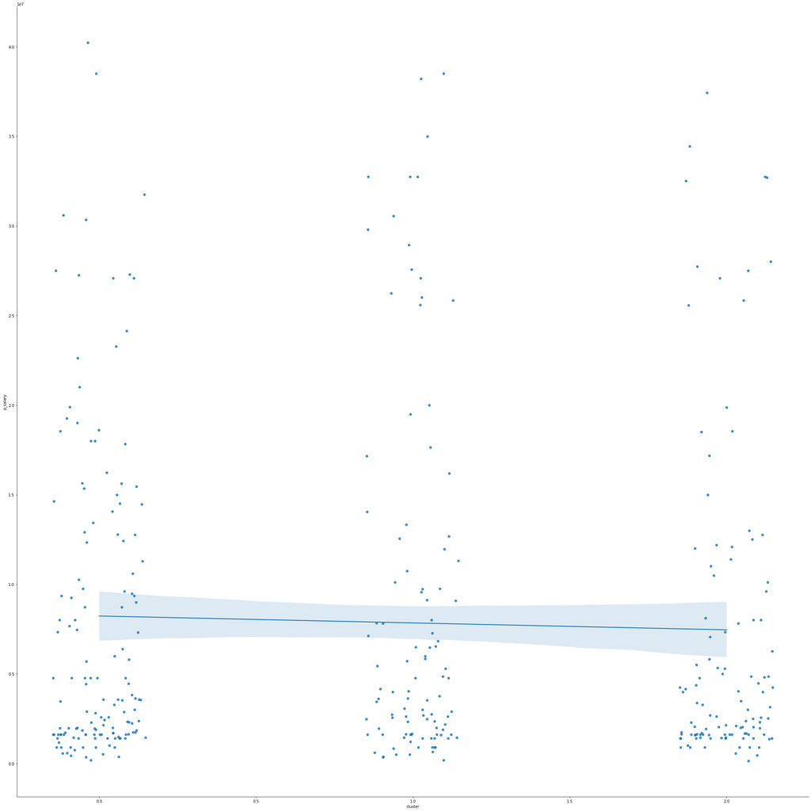

```python
%matplotlib inline
from sklearn.cluster import KMeans

k_means = KMeans(init='k-means++', n_clusters=3, random_state=0)
k_means.fit(df.drop(['player', 'position', 'team'], axis=1))
clus = pd.DataFrame(k_means.labels_, columns = ['cluster'])
df1 = df2.join(clus)


sns.lmplot("cluster", "p_salary", df1, x_jitter=.15, y_jitter=.15,height=30)
```

# What the Dataframe is representing

```python
df2['team'].describe()
```

```
count     359
unique     31
top       TOT
freq       48
Name: team, dtype: object
```

```python
df2.groupby('team').size()
```

```
team
ATL    10
BOS    14
BRK    14
CHI    12
CHO     9
CLE     7
DAL     8
DEN     8
DET    12
GSW     9
HOU     9
IND    12
LAC    12
LAL    11
MEM     8
MIA    12
MIL    12
MIN     5
NOP    10
NYK    12
OKC    12
ORL     8
PHI    12
PHO    13
POR     9
SAC     7
SAS    12
TOR    14
TOT    48
UTA     9
WAS     9
dtype: int64
```

```python
df2['position'].describe()
```

```
count     359
unique     13
top        SG
freq       86
Name: position, dtype: object
```

```python
df2.groupby('position').size()
```

```
position
C        65
PF       72
PF-C      5
PF-SF     1
PG       60
PG-SG     1
SF       60
SF-C      1
SF-PF     3
SF-SG     2
SG       86
SG-PG     2
SG-SF     1
dtype: int64
```

# Basic Data Visualization

```python
teams = df1.groupby('team').mean().sort_values(by=['p_salary'])
teams
```

| team | age | games | games_started | mins_per_g | fg_per_g | fga_per_g | fg_pct | fg3_per_g | fg3a_per_g | fg3_pct | ... | drb_per_g | trb_per_g | ast_per_g | stl_per_g | blk_per_g | tov_per_g | pf_per_g | pts_per_g | p_salary | cluster |
| --- | --- | --- | --- | --- | --- | --- | --- | --- | --- | --- | --- | --- | --- | --- | --- | --- | --- | --- | --- | --- | --- |
| MIN | 21.200000 | 38.600000 | 15.200000 | 19.500000 | 2.900000 | 6.960000 | 0.410800 | 0.800000 | 2.800000 | 0.268600 | ... | 2.120000 | 3.040000 | 1.300000 | 0.700000 | 0.440000 | 0.920000 | 1.940000 | 7.940000 | 2.844923e+06 | 1.400000 |
| ATL | 25.200000 | 45.300000 | 22.400000 | 20.720000 | 3.620000 | 8.020000 | 0.445800 | 1.050000 | 3.170000 | 0.249900 | ... | 2.880000 | 3.720000 | 2.280000 | 0.650000 | 0.470000 | 1.480000 | 1.980000 | 10.110000 | 4.188471e+06 | 1.000000 |
| MEM | 23.250000 | 54.250000 | 22.250000 | 21.050000 | 3.850000 | 8.225000 | 0.467000 | 0.937500 | 2.687500 | 0.342125 | ... | 2.562500 | 3.237500 | 2.700000 | 0.687500 | 0.362500 | 1.337500 | 1.687500 | 10.112500 | 5.409066e+06 | 1.000000 |
| BRK | 26.357143 | 40.285714 | 24.642857 | 22.357143 | 3.771429 | 8.628571 | 0.436214 | 1.250000 | 3.664286 | 0.295786 | ... | 3.064286 | 3.900000 | 2.342857 | 0.657143 | 0.371429 | 1.371429 | 1.935714 | 10.428571 | 5.597966e+06 | 0.642857 |
| UTA | 24.888889 | 46.333333 | 18.000000 | 17.722222 | 3.000000 | 6.677778 | 0.476333 | 1.066667 | 2.833333 | 0.422667 | ... | 2.111111 | 2.711111 | 2.011111 | 0.455556 | 0.200000 | 1.133333 | 1.500000 | 8.288889 | 6.172572e+06 | 0.444444 |
| PHO | 24.076923 | 45.230769 | 19.692308 | 20.846154 | 3.623077 | 7.623077 | 0.462154 | 0.976923 | 2.607692 | 0.329692 | ... | 2.961538 | 3.846154 | 2.500000 | 0.638462 | 0.376923 | 1.284615 | 1.953846 | 9.746154 | 6.215703e+06 | 0.923077 |
| DET | 25.166667 | 44.166667 | 20.583333 | 22.208333 | 3.425000 | 7.833333 | 0.426000 | 1.200000 | 3.383333 | 0.350250 | ... | 2.300000 | 2.908333 | 2.383333 | 0.575000 | 0.325000 | 1.241667 | 1.708333 | 9.625000 | 6.557636e+06 | 1.000000 |
| DAL | 27.750000 | 51.750000 | 14.625000 | 19.637500 | 2.775000 | 5.762500 | 0.472375 | 1.050000 | 2.700000 | 0.367750 | ... | 2.425000 | 3.200000 | 1.637500 | 0.587500 | 0.362500 | 0.750000 | 1.600000 | 7.525000 | 6.758592e+06 | 0.500000 |
| TOT | 27.166667 | 44.500000 | 14.062500 | 18.681250 | 2.800000 | 6.410417 | 0.440438 | 0.956250 | 2.806250 | 0.306500 | ... | 2.677083 | 3.452083 | 1.581250 | 0.606250 | 0.427083 | 1.085417 | 1.822917 | 7.718750 | 6.762614e+06 | 0.958333 |
| NYK | 24.833333 | 46.750000 | 22.250000 | 20.116667 | 3.166667 | 7.441667 | 0.417333 | 0.841667 | 2.625000 | 0.300500 | ... | 2.683333 | 3.458333 | 2.041667 | 0.625000 | 0.258333 | 1.150000 | 1.683333 | 8.416667 | 7.095309e+06 | 0.750000 |
| CHI | 24.500000 | 42.250000 | 17.583333 | 20.166667 | 3.558333 | 8.108333 | 0.454333 | 1.225000 | 3.533333 | 0.315917 | ... | 2.608333 | 3.266667 | 1.766667 | 0.908333 | 0.325000 | 1.125000 | 1.783333 | 9.616667 | 7.423739e+06 | 0.833333 |
| WAS | 25.222222 | 49.000000 | 32.444444 | 23.377778 | 4.300000 | 9.100000 | 0.475667 | 0.988889 | 2.755556 | 0.332778 | ... | 3.100000 | 4.200000 | 2.500000 | 0.666667 | 0.477778 | 1.422222 | 2.266667 | 11.600000 | 7.457017e+06 | 1.000000 |
| GSW | 24.333333 | 43.000000 | 18.222222 | 23.255556 | 3.633333 | 8.577778 | 0.422000 | 0.955556 | 3.388889 | 0.269000 | ... | 3.411111 | 4.411111 | 2.977778 | 0.833333 | 0.422222 | 1.600000 | 2.033333 | 10.222222 | 7.760330e+06 | 0.444444 |
| SAC | 26.142857 | 60.000000 | 32.285714 | 21.300000 | 3.485714 | 7.642857 | 0.453714 | 1.242857 | 3.185714 | 0.308571 | ... | 2.757143 | 3.500000 | 2.100000 | 0.600000 | 0.300000 | 1.114286 | 1.757143 | 9.342857 | 7.780149e+06 | 1.142857 |
| IND | 25.083333 | 48.916667 | 24.416667 | 22.033333 | 3.641667 | 7.991667 | 0.459333 | 0.991667 | 2.816667 | 0.316083 | ... | 3.275000 | 4.100000 | 2.275000 | 0.650000 | 0.491667 | 1.216667 | 1.866667 | 9.741667 | 7.942772e+06 | 0.666667 |
| CHO | 24.333333 | 42.666667 | 20.555556 | 22.744444 | 3.222222 | 7.455556 | 0.426667 | 0.977778 | 2.822222 | 0.331222 | ... | 3.033333 | 4.066667 | 1.988889 | 0.688889 | 0.322222 | 1.188889 | 1.844444 | 8.722222 | 8.033790e+06 | 1.111111 |
| NOP | 23.300000 | 51.800000 | 30.900000 | 24.720000 | 4.620000 | 9.370000 | 0.499100 | 1.030000 | 2.940000 | 0.320000 | ... | 3.920000 | 5.400000 | 2.790000 | 0.790000 | 0.590000 | 1.740000 | 2.200000 | 12.160000 | 8.087841e+06 | 0.900000 |
| BOS | 25.000000 | 54.428571 | 25.571429 | 20.835714 | 3.550000 | 7.771429 | 0.449071 | 1.092857 | 3.014286 | 0.331214 | ... | 3.000000 | 3.928571 | 1.964286 | 0.685714 | 0.464286 | 1.114286 | 1.828571 | 9.757143 | 8.261620e+06 | 1.357143 |
| MIA | 26.416667 | 44.000000 | 28.083333 | 22.458333 | 3.441667 | 7.550000 | 0.476583 | 1.016667 | 2.800000 | 0.270417 | ... | 3.700000 | 4.566667 | 2.350000 | 0.641667 | 0.450000 | 1.316667 | 1.991667 | 9.641667 | 8.316280e+06 | 1.416667 |
| TOR | 26.142857 | 47.357143 | 25.285714 | 21.464286 | 3.535714 | 7.814286 | 0.442429 | 1.292857 | 3.428571 | 0.380357 | ... | 3.192857 | 3.971429 | 2.285714 | 0.785714 | 0.428571 | 1.264286 | 1.914286 | 9.928571 | 8.675311e+06 | 0.928571 |
| SAS | 26.833333 | 55.583333 | 27.750000 | 21.858333 | 3.916667 | 8.308333 | 0.472417 | 1.041667 | 2.725000 | 0.353917 | ... | 3.141667 | 3.825000 | 2.141667 | 0.658333 | 0.391667 | 1.083333 | 1.666667 | 10.683333 | 8.768074e+06 | 1.083333 |
| MIL | 29.166667 | 59.083333 | 29.666667 | 21.158333 | 3.916667 | 8.183333 | 0.464583 | 1.216667 | 3.425000 | 0.328583 | ... | 3.566667 | 4.391667 | 2.408333 | 0.683333 | 0.500000 | 1.358333 | 1.683333 | 10.725000 | 9.161955e+06 | 0.916667 |
| LAL | 30.000000 | 58.636364 | 29.727273 | 21.545455 | 3.900000 | 8.081818 | 0.483000 | 0.954545 | 2.736364 | 0.389091 | ... | 3.363636 | 4.318182 | 2.463636 | 0.800000 | 0.609091 | 1.409091 | 1.845455 | 10.372727 | 9.223773e+06 | 0.909091 |
| OKC | 25.416667 | 50.250000 | 24.000000 | 19.916667 | 2.850000 | 6.300000 | 0.440583 | 0.833333 | 2.450000 | 0.317500 | ... | 2.925000 | 3.758333 | 1.466667 | 0.633333 | 0.466667 | 0.925000 | 1.841667 | 7.875000 | 9.226929e+06 | 1.166667 |
| LAC | 26.916667 | 53.333333 | 24.500000 | 21.183333 | 3.875000 | 8.350000 | 0.458000 | 1.241667 | 3.233333 | 0.312667 | ... | 3.341667 | 4.275000 | 2.191667 | 0.650000 | 0.400000 | 1.241667 | 1.908333 | 10.983333 | 9.358103e+06 | 1.166667 |
| ORL | 24.125000 | 54.000000 | 30.500000 | 23.487500 | 3.862500 | 8.587500 | 0.456875 | 1.100000 | 3.112500 | 0.313875 | ... | 3.175000 | 4.200000 | 2.062500 | 0.900000 | 0.700000 | 1.187500 | 1.850000 | 10.437500 | 9.397466e+06 | 0.625000 |
| PHI | 25.416667 | 52.666667 | 29.833333 | 22.191667 | 3.808333 | 8.108333 | 0.451667 | 1.008333 | 2.758333 | 0.301583 | ... | 3.275000 | 4.200000 | 2.433333 | 0.758333 | 0.558333 | 1.358333 | 2.058333 | 10.258333 | 1.016101e+07 | 0.750000 |
| CLE | 25.714286 | 57.000000 | 43.000000 | 26.357143 | 4.357143 | 9.742857 | 0.436143 | 1.257143 | 3.485714 | 0.332714 | ... | 3.500000 | 4.657143 | 2.600000 | 0.671429 | 0.257143 | 1.771429 | 1.900000 | 11.628571 | 1.038035e+07 | 0.571429 |
| POR | 26.000000 | 51.555556 | 33.333333 | 26.855556 | 4.855556 | 10.344444 | 0.465889 | 1.411111 | 3.611111 | 0.386000 | ... | 3.944444 | 5.111111 | 2.322222 | 0.644444 | 0.622222 | 1.377778 | 2.333333 | 13.088889 | 1.130744e+07 | 1.000000 |
| HOU | 27.666667 | 51.111111 | 24.555556 | 23.133333 | 4.444444 | 10.088889 | 0.449111 | 1.722222 | 5.022222 | 0.297000 | ... | 2.900000 | 3.622222 | 2.444444 | 0.855556 | 0.388889 | 1.577778 | 2.055556 | 13.011111 | 1.134221e+07 | 0.777778 |
| DEN | 27.125000 | 60.875000 | 35.500000 | 25.775000 | 4.187500 | 8.975000 | 0.477625 | 1.162500 | 3.137500 | 0.322750 | ... | 3.050000 | 4.100000 | 2.525000 | 0.862500 | 0.487500 | 1.187500 | 2.075000 | 11.150000 | 1.154829e+07 | 0.375000 |

31 rows × 28 columns